# Data Cleaning + Initial EDA

```r
# Load packages and raw data.

library(dplyr)
library(janitor)
library(lubridate)
library(stringr)
library(skimr)
library(ggplot2)

load("./data/raw_data.Rda")
load("./data/postcodes.Rda")
```

What does the contacts dataset look like?

```r
contacts_raw %>%
  clean_names() %>%
  str()
```

```
## tibble [66,654 x 19] (S3: tbl_df/tbl/data.frame)
##  $ supporter_id                         : chr [1:66654] "678350" "678352" "678354" "678355" ...
##  $ age                                  : num [1:66654] NA NA NA NA NA NA NA NA NA NA ...
##  $ gender                               : chr [1:66654] "Female" "Male" "Male" NA ...
##  $ religion                             : chr [1:66654] NA NA NA NA ...
##  $ mailing_state_province               : chr [1:66654] "NSW" "QLD" "VIC" "QLD" ...
##  $ mailing_zip_postal_code              : chr [1:66654] "2077" "4075" "3915" "4075" ...
##  $ mailing_country                      : chr [1:66654] "AUSTRALIA" "AUSTRALIA" "AUSTRALIA" "AUSTRALIA" ...
##  $ af_p_communication_preference_encoded: chr [1:66654] NA NA NA "{AFP-DNMail}" ...
##  $ bequest_status                       : chr [1:66654] NA NA NA NA ...
##  $ total_number_of_gifts                : num [1:66654] 1 3 1 2 1 6 2 1 1 1 ...
##  $ number_of_gifts_last_365_days        : num [1:66654] 0 0 0 0 0 0 0 0 0 0 ...
##  $ number_of_gifts_this_year            : num [1:66654] 0 0 0 0 0 0 0 0 0 0 ...
##  $ number_of_gifts_last_year            : num [1:66654] 0 0 0 0 0 1 0 0 0 0 ...
##  $ number_of_gifts_two_years_ago        : num [1:66654] 0 1 0 0 0 1 0 0 0 0 ...
##  $ total_gifts                          : num [1:66654] 50 175 20 15 50 220 30 5 25 40 ...
##  $ total_gifts_last_365_days            : num [1:66654] 0 0 0 0 0 0 0 0 0 0 ...
##  $ total_gifts_last_year                : num [1:66654] 0 0 0 0 0 50 0 0 0 0 ...
##  $ total_gifts_this_year                : num [1:66654] 0 0 0 0 0 0 0 0 0 0 ...
##  $ total_gifts_two_years_ago            : num [1:66654] 0 100 0 0 0 50 0 0 0 0 ...
```

- Let’s do some column renaming and move on.

```r
postcode_join <- postcode_data %>%
  select(postcode, state_y = state) %>%
  distinct(postcode, state_y) %>%
  group_by(postcode) %>%
  slice_head(n = 1) %>%
  ungroup()

contacts <- contacts_raw %>%
  clean_names() %>%
  rename(state = mailing_state_province,
         postcode = mailing_zip_postal_code,
         country = mailing_country,
         comms_preference = af_p_communication_preference_encoded,
         num_gifts_last_365_days = number_of_gifts_last_365_days,
         num_gifts_this_year = number_of_gifts_this_year,
         num_gifts_last_year = number_of_gifts_last_year,
         num_gifts_two_years_ago = number_of_gifts_two_years_ago) %>%
  mutate(avg_gift_amount = if_else(total_number_of_gifts > 0, total_gifts / total_number_of_gifts, 0),
         avg_gift_amount_last_365_days = if_else(num_gifts_last_365_days > 0, total_gifts_last_365_days / num_gifts_last_365_days, 0),
         avg_gift_amount_this_year = if_else(num_gifts_this_year > 0, total_gifts_this_year / num_gifts_this_year, 0),
         avg_gift_amount_last_year = if_else(num_gifts_last_year > 0, total_gifts_last_year / num_gifts_last_year, 0),
         avg_gift_amount_two_years_ago = if_else(num_gifts_two_years_ago > 0, total_gifts_two_years_ago / num_gifts_two_years_ago, 0)) %>%
  mutate(country = str_to_title(country)) %>%
  left_join(postcode_join, by = "postcode") %>%
  mutate(state = case_when(country == "Australia" & is.na(state) ~ state_y,
                           TRUE ~ state)) %>%
  select(-state_y) %>%
  mutate(country = case_when(is.na(country) & grepl("(NSW|QLD|WA|ACT|NT)", state) ~ "Australia",
                             TRUE ~ country)) %>%
  mutate(state = case_when(state == "N.S.W." ~ "NSW",
                           state == "MAN" ~ "MANAWATU-WANGANUI",
                           state == "WAI" ~ "WAIKATO",
                           state == "CAN" ~ "CANTERBURY",
                           state == "VICTORIA" & country == "Australia" ~ "VIC",
                           state == "QUEENSLAND" ~ "QLD",
                           state == "OTA" ~ "OTAGO",
                           state == "CA" ~ "CALIFORNIA",
                           state == "BOP" ~ "BAY OF PLENTY",
                           state == "AKL" ~ "AUCKLAND",
                           state == "WEL" ~ "WELLINGTON",
                           TRUE ~ state))
```

```r
# Cleaning comms preference.
contacts %>%
  count(bequest_status, sort = TRUE) %>% View()
```

What are the characteristics of the data?

```r
contacts %>% skim()
```

Data summary

| Name | Piped data |
| --- | --- |
| Number of rows | 66654 |
| Number of columns | 24 |
| _______________________ |  |
| Column type frequency: |  |
| character | 8 |
| numeric | 16 |
| ________________________ |  |
| Group variables | None |

**Variable type: character**

| skim_variable | n_missing | complete_rate | min | max | empty | n_unique | whitespace |
| --- | --- | --- | --- | --- | --- | --- | --- |
| supporter_id | 0 | 1.00 | 6 | 6 | 0 | 66654 | 0 |
| gender | 23065 | 0.65 | 4 | 6 | 0 | 2 | 0 |
| religion | 38521 | 0.42 | 7 | 9 | 0 | 3 | 0 |
| state | 4382 | 0.93 | 1 | 17 | 0 | 72 | 0 |
| postcode | 4383 | 0.93 | 3 | 8 | 0 | 2491 | 0 |
| country | 941 | 0.99 | 3 | 20 | 0 | 57 | 0 |
| comms_preference | 35437 | 0.47 | 10 | 62 | 0 | 32 | 0 |
| bequest_status | 66533 | 0.00 | 8 | 8 | 0 | 2 | 0 |

**Variable type: numeric**

| skim_variable | n_missing | complete_rate | mean | sd | p0 | p25 | p50 | p75 | p100 | hist |
| --- | --- | --- | --- | --- | --- | --- | --- | --- | --- | --- |
| age | 59078 | 0.11 | 67.69 | 22.46 | 20 | 55 | 75 | 85 | 111.00 | ▃▂▅▇▁ |
| total_number_of_gifts | 0 | 1.00 | 6.69 | 64.29 | 0 | 1 | 1 | 5 | 15902.00 | ▇▁▁▁▁ |
| num_gifts_last_365_days | 0 | 1.00 | 0.45 | 1.71 | 0 | 0 | 0 | 0 | 27.00 | ▇▁▁▁▁ |
| num_gifts_this_year | 0 | 1.00 | 0.23 | 0.88 | 0 | 0 | 0 | 0 | 16.00 | ▇▁▁▁▁ |
| num_gifts_last_year | 0 | 1.00 | 0.64 | 1.75 | 0 | 0 | 0 | 1 | 30.00 | ▇▁▁▁▁ |
| num_gifts_two_years_ago | 0 | 1.00 | 0.54 | 1.70 | 0 | 0 | 0 | 0 | 29.00 | ▇▁▁▁▁ |
| total_gifts | 0 | 1.00 | 696.13 | 10188.86 | 0 | 20 | 50 | 250 | 2358247.01 | ▇▁▁▁▁ |
| total_gifts_last_365_days | 0 | 1.00 | 47.83 | 415.38 | 0 | 0 | 0 | 0 | 43961.35 | ▇▁▁▁▁ |
| total_gifts_last_year | 0 | 1.00 | 58.53 | 604.00 | 0 | 0 | 0 | 25 | 91440.00 | ▇▁▁▁▁ |
| total_gifts_this_year | 0 | 1.00 | 28.70 | 290.84 | 0 | 0 | 0 | 0 | 41500.00 | ▇▁▁▁▁ |
| total_gifts_two_years_ago | 0 | 1.00 | 55.98 | 449.60 | 0 | 0 | 0 | 0 | 68077.86 | ▇▁▁▁▁ |
| avg_gift_amount | 0 | 1.00 | 62.47 | 364.51 | 0 | 10 | 30 | 60 | 64672.24 | ▇▁▁▁▁ |
| avg_gift_amount_last_365_days | 0 | 1.00 | 26.17 | 294.23 | 0 | 0 | 0 | 0 | 43961.35 | ▇▁▁▁▁ |
| avg_gift_amount_this_year | 0 | 1.00 | 19.55 | 199.94 | 0 | 0 | 0 | 0 | 25000.00 | ▇▁▁▁▁ |
| avg_gift_amount_last_year | 0 | 1.00 | 32.69 | 297.78 | 0 | 0 | 0 | 20 | 43961.35 | ▇▁▁▁▁ |
| avg_gift_amount_two_years_ago | 0 | 1.00 | 28.20 | 205.02 | 0 | 0 | 0 | 0 | 25000.00 | ▇▁▁▁▁ |

- Number of gifts appears to be the number of times each person donated, while total gifts appears to be the total monetary value.
- Mix of character and numeric columns.
- Supporters are unique (no duplicates).
- Aside from age, numeric variables have no missing values.
- All gift-related columns appear to have outlying values where a handful of people donated extremely large amounts.
- Total gifts and number of gifts are not limited to this year and the last 2 years.
- Additional columns for ML:
  - Avg gift amount/number over whole history vs. last 2 years.
- Remove deceased.
- Can probably lump NAs with Unknown for religion.

To-do: * Specifying the outcome of the donation could have an impact on giving? Could possibly do some A/B testing to verify?

```r
contacts %>%
  count(state, sort = TRUE) %>%
  print(n = Inf)
```

```
## # A tibble: 73 x 2
##    state                 n
##    <chr>             <int>
##  1 VIC               19453
##  2 NSW               16914
##  3 QLD                8785
##  4 SA                 7230
##  5 WA                 5405
##  6 <NA>               4382
##  7 ACT                1891
##  8 TAS                1853
##  9 NT                  363
## 10 CANTERBURY           66
## 11 WELLINGTON           56
## 12 AUCKLAND             48
```

[output cut: 61 more lines]

- State field needs to be cleaned up. (Eg: Bay of Plenty appears to be the same as BOP etc.)

```r
contacts %>%
  filter(is.na(state) & !is.na(postcode)) %>%
  count(country, sort = TRUE)
```

```
## # A tibble: 11 x 2
##    country            n
##    <chr>          <int>
##  1 New Zealand      124
##  2 <NA>              94
##  3 United Kingdom    12
##  4 Australia          1
##  5 Belgium            1
##  6 Canada             1
##  7 France             1
##  8 Italy              1
##  9 Norway             1
## 10 Sweden             1
## 11 Thailand           1
```

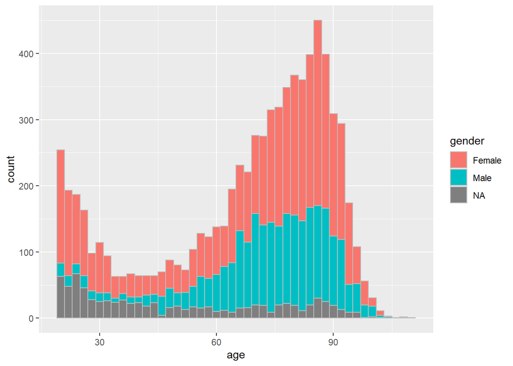

```r
contacts %>%
  ggplot(aes(age, fill = gender)) +
  geom_histogram(binwidth = 2, color = "grey")
```

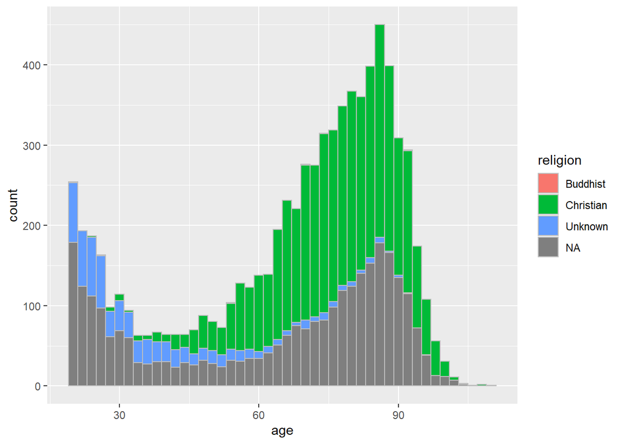

```r
contacts %>%
  ggplot(aes(age, fill = religion)) +
  geom_histogram(binwidth = 2, color = "grey")
```

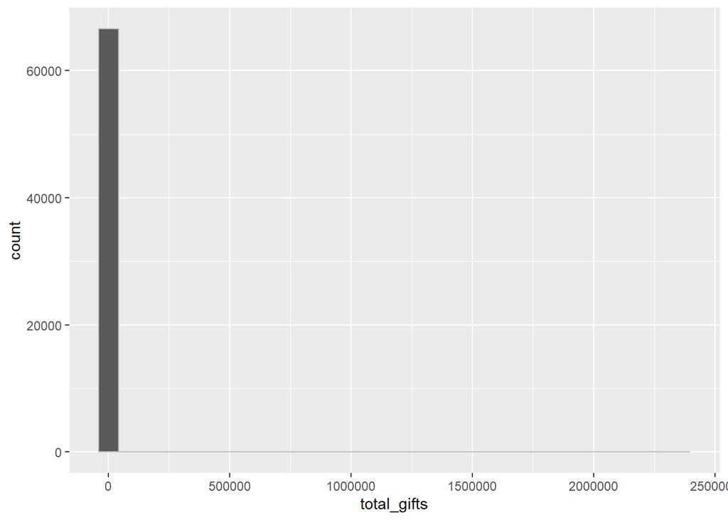

```r
contacts %>%
  mutate(total_gifts = 5 * (total_gifts %/% 5)) %>%
  ggplot(aes(total_gifts)) +
  geom_histogram(color = "grey")
```

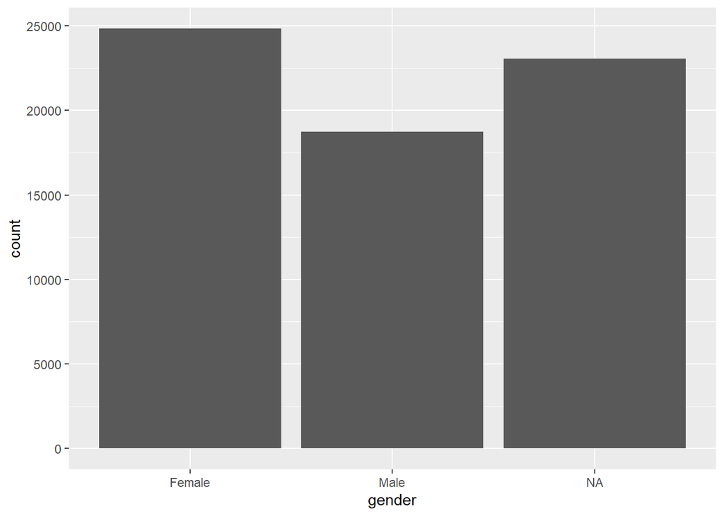

```r
contacts %>%
  ggplot(aes(gender)) +
  geom_bar(stat = "count")
```

- Seems like age is a strong predictor of giving.

```r
contacts %>%
  filter(total_number_of_gifts > 20)
```

```
## # A tibble: 4,793 x 24
##    supporter_id   age gender religion  state postcode country   comms_preference
##    <chr>        <dbl> <chr>  <chr>     <chr> <chr>    <chr>     <chr>
##  1 678393          NA Male   Christian SA    5118     Australia <NA>
##  2 678414          NA Male   Christian VIC   3095     Australia {AFP-DNEmail}{A~
##  3 678482          NA Male   Christian QLD   4069     Australia <NA>
##  4 678499          88 Male   Christian NSW   2118     Australia {AFP-DNCall}
##  5 678503          NA Male   Christian VIC   3149     Australia {AFP-DNMail}
##  6 678521          67 Female Christian VIC   3104     Australia {AFP-DNCall}{AF~
##  7 678567          88 Female Christian VIC   3677     Australia <NA>
##  8 678591          NA Female Christian QLD   4700     Australia <NA>
##  9 678614          NA Male   Christian ACT   2615     Australia <NA>
## 10 678615          68 Female Christian NSW   2680     Australia {AFP-DNEmail}
## # ... with 4,783 more rows, and 16 more variables: bequest_status <chr>,
## #   total_number_of_gifts <dbl>, num_gifts_last_365_days <dbl>,
## #   num_gifts_this_year <dbl>, num_gifts_last_year <dbl>,
## #   num_gifts_two_years_ago <dbl>, total_gifts <dbl>,
## #   total_gifts_last_365_days <dbl>, total_gifts_last_year <dbl>,
## #   total_gifts_this_year <dbl>, total_gifts_two_years_ago <dbl>,
## #   avg_gift_amount <dbl>, avg_gift_amount_last_365_days <dbl>, ...
```

[figure not shown]

```r
contacts %>%
  ggplot(aes(total_number_of_gifts))
```

```r
# Clean state and postcode data.
contacts
```

```
## # A tibble: 66,654 x 24
##    supporter_id   age gender religion state postcode country   comms_preference
##    <chr>        <dbl> <chr>  <chr>    <chr> <chr>    <chr>     <chr>
##  1 678350          NA Female <NA>     NSW   2077     Australia <NA>
##  2 678352          NA Male   <NA>     QLD   4075     Australia <NA>
##  3 678354          NA Male   <NA>     VIC   3915     Australia <NA>
##  4 678355          NA <NA>   <NA>     QLD   4075     Australia {AFP-DNMail}
##  5 678364          NA Male   <NA>     NSW   2594     Australia <NA>
##  6 678368          NA Female <NA>     NSW   2153     Australia <NA>
##  7 678374          NA <NA>   <NA>     TAS   7000     Australia <NA>
##  8 678376          NA Female <NA>     QLD   4650     Australia <NA>
##  9 678381          NA Male   <NA>     QLD   4055     Australia {AFP-DNMail}
## 10 678383          NA Male   <NA>     QLD   4070     Australia <NA>
## # ... with 66,644 more rows, and 16 more variables: bequest_status <chr>,
## #   total_number_of_gifts <dbl>, num_gifts_last_365_days <dbl>,
## #   num_gifts_this_year <dbl>, num_gifts_last_year <dbl>,
## #   num_gifts_two_years_ago <dbl>, total_gifts <dbl>,
## #   total_gifts_last_365_days <dbl>, total_gifts_last_year <dbl>,
## #   total_gifts_this_year <dbl>, total_gifts_two_years_ago <dbl>,
## #   avg_gift_amount <dbl>, avg_gift_amount_last_365_days <dbl>, ...
```

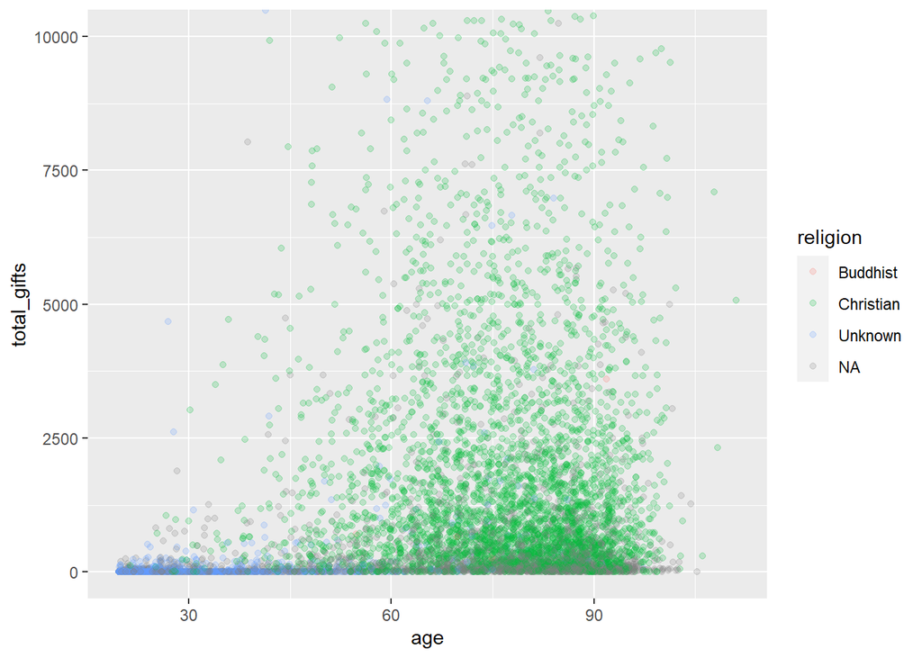

```r
contacts %>%
  ggplot(aes(age, total_gifts, color = religion)) +
  geom_point(alpha = 0.2, position = "jitter") +
  coord_cartesian(ylim = c(0,10000))
```

- Being older and christian seems to be correlated with giving.

```r
contacts %>%
  filter(!is.na(postcode)) %>%
  left_join(postcode_data, by = "postcode") %>%
  select(state.x, postcode, state.y, country) %>%
  filter(!is.na(state.y)) %>%
  filter(country != "Australia") %>%
  distinct(country)
```

```
## # A tibble: 6 x 1
##   country
##   <chr>
## 1 New Zealand
## 2 United Kingdom
## 3 Slovenia
## 4 Mexico
## 5 Switzerland
## 6 Norway
```

```r
contacts %>% distinct(postcode)
```

```
## # A tibble: 2,492 x 1
##    postcode
##    <chr>
##  1 2077
##  2 4075
##  3 3915
##  4 2594
##  5 2153
##  6 7000
##  7 4650
##  8 4055
##  9 4070
## 10 2256
## # ... with 2,482 more rows
```

```r
transactions <- transactions_raw %>%
  clean_names() %>%
  mutate(date = ymd(date))
```

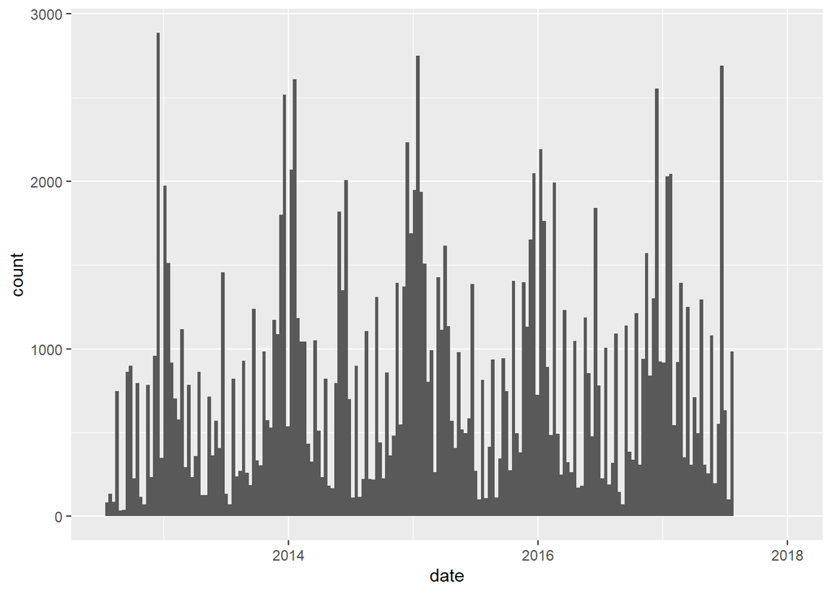

```r
transactions %>%
  ggplot(aes(date)) +
  geom_histogram(binwidth = 10)
```

```r
transactions %>%
  count(source, sort = TRUE)
```

```
## # A tibble: 2,397 x 2
##    source                   n
##    <chr>                <int>
##  1 RG-AFP-EOFY15        18772
##  2 CB13-NEWS-IND         2295
##  3 RG-RC16-TF-1607       1842
##  4 AFP-NEWS-ACQ-1405-IN  1829
##  5 CB12-CH-ACV-200       1776
##  6 RG-AFP-OUTB-1507      1264
##  7 EM-CON-SYR-0912-IND   1206
##  8 CB12-NEWS-IND-C       1195
##  9 CB13-FP-CH-ACV-200    1097
## 10 CB12-NEWS-IND-P       1073
## # ... with 2,387 more rows
```

```r
contacts %>%
  filter(total_number_of_gifts > 0)
```

```
## # A tibble: 57,000 x 24
##    supporter_id   age gender religion state postcode country   comms_preference
##    <chr>        <dbl> <chr>  <chr>    <chr> <chr>    <chr>     <chr>
##  1 678350          NA Female <NA>     NSW   2077     Australia <NA>
##  2 678352          NA Male   <NA>     QLD   4075     Australia <NA>
##  3 678354          NA Male   <NA>     VIC   3915     Australia <NA>
##  4 678355          NA <NA>   <NA>     QLD   4075     Australia {AFP-DNMail}
##  5 678364          NA Male   <NA>     NSW   2594     Australia <NA>
##  6 678368          NA Female <NA>     NSW   2153     Australia <NA>
##  7 678374          NA <NA>   <NA>     TAS   7000     Australia <NA>
##  8 678376          NA Female <NA>     QLD   4650     Australia <NA>
##  9 678381          NA Male   <NA>     QLD   4055     Australia {AFP-DNMail}
## 10 678383          NA Male   <NA>     QLD   4070     Australia <NA>
## # ... with 56,990 more rows, and 16 more variables: bequest_status <chr>,
## #   total_number_of_gifts <dbl>, num_gifts_last_365_days <dbl>,
## #   num_gifts_this_year <dbl>, num_gifts_last_year <dbl>,
## #   num_gifts_two_years_ago <dbl>, total_gifts <dbl>,
## #   total_gifts_last_365_days <dbl>, total_gifts_last_year <dbl>,
## #   total_gifts_this_year <dbl>, total_gifts_two_years_ago <dbl>,
## #   avg_gift_amount <dbl>, avg_gift_amount_last_365_days <dbl>, ...
```

```r
contacts %>%
  filter(total_number_of_gifts == 0) %>%
  inner_join(transactions, by = "supporter_id") %>%
  group_by(supporter_id) %>%
  slice_max(date) %>%
  arrange(desc(date))
```

```
## # A tibble: 1,951 x 31
## # Groups:   supporter_id [1,949]
##    supporter_id   age gender religion  state postcode country   comms_preference
##    <chr>        <dbl> <chr>  <chr>     <chr> <chr>    <chr>     <chr>
##  1 777501          NA Male   Christian VIC   3188     Australia <NA>
##  2 778159          NA Female Christian VIC   3065     Australia {AFP-DNMail}
##  3 741224          NA Female Christian QLD   4380     Australia <NA>
##  4 777538          NA Male   Christian VIC   3124     Australia <NA>
##  5 777591          NA Male   Christian VIC   3216     <NA>      <NA>
##  6 741713          NA Male   <NA>      SA    5166     Australia <NA>
##  7 777432          NA Male   Christian VIC   3563     Australia <NA>
##  8 777769          NA Female Christian VIC   3300     Australia <NA>
##  9 733475          NA <NA>   <NA>      SA    5023     Australia <NA>
## 10 776508          NA Female Christian QLD   4051     Australia <NA>
## # ... with 1,941 more rows, and 23 more variables: bequest_status <chr>,
## #   total_number_of_gifts <dbl>, num_gifts_last_365_days <dbl>,
## #   num_gifts_this_year <dbl>, num_gifts_last_year <dbl>,
## #   num_gifts_two_years_ago <dbl>, total_gifts <dbl>,
## #   total_gifts_last_365_days <dbl>, total_gifts_last_year <dbl>,
## #   total_gifts_this_year <dbl>, total_gifts_two_years_ago <dbl>,
## #   avg_gift_amount <dbl>, avg_gift_amount_last_365_days <dbl>, ...
```

- Can create separate features for type of campaign given to.
- Histogram of number of times individuals have given.
- Correlation between do not mail reason and amount given.
- Amounts given by source/source_2.

Some questions:

total gifts appears to be across all time. why are there transactions recorded for individuals who have 0 total gifts? Eg: 682306, 692862 does transactions contain the full subset of transactions for the given individuals who are in the dataset for that time period?

```r
nonfin_actions <- nonfin_actions_raw %>%
  clean_names() %>%
  rename(action_name = non_financial_action_non_financial_action_name,
         record_type = non_financial_action_record_type)
```

```r
nonfin_actions %>% skim()
```

Data summary

| Name | Piped data |
| --- | --- |
| Number of rows | 14168 |
| Number of columns | 6 |
| _______________________ |  |
| Column type frequency: |  |
| character | 6 |
| ________________________ |  |
| Group variables | None |

**Variable type: character**

| skim_variable | n_missing | complete_rate | min | max | empty | n_unique | whitespace |
| --- | --- | --- | --- | --- | --- | --- | --- |
| supporter_id | 0 | 1.00 | 6 | 6 | 0 | 13155 | 0 |
| action_type | 0 | 1.00 | 17 | 45 | 0 | 4 | 0 |
| action_name | 0 | 1.00 | 3 | 27 | 0 | 53 | 0 |
| primary_campaign | 0 | 1.00 | 8 | 22 | 0 | 15 | 0 |
| response_channel | 218 | 0.98 | 13 | 19 | 0 | 2 | 0 |
| record_type | 0 | 1.00 | 5 | 15 | 0 | 2 | 0 |

```r
nonfin_actions %>%
  count(action_type, action_name, sort = T) %>% print(n = 55)
```

```
## # A tibble: 53 x 3
##    action_type                                   action_name                   n
##    <chr>                                         <chr>                     <int>
##  1 Ration Challenge Registrant/ Participant (EO) RC16-EO                    7996
##  2 Ration Challenge Registrant/ Participant (EO) RC15-EO                    1645
##  3 Signed a Petition                             AFP-CAM-IPD-1309-WEB        620
##  4 Signed a Petition                             AFP-CAM-IPD-1309-ORG        520
##  5 Signed a Petition                             AFP-CAM-MTEP-1308-WEB       441
##  6 Signed a Petition                             AFP-CAM-MYR-1403-DM         422
##  7 Ration Challenge Registrant/ Participant (EO) RC16-PREREG-CH              242
##  8 Signed a Petition                             AFP-CAM-REF-1505-CHG5       124
##  9 Signed a Petition                             AFP-CAM-REF-1607-CHG        124
## 10 Ration Challenge Registrant/ Participant (EO) Yes                         121
## 11 Ration Challenge Registrant/ Participant (EO) RC16-PREREG                 120
## 12 Signed a Petition                             AFP-CAM-OPT-1505-WEB        120
```

[output cut: 41 more lines]

```r
nonfin_actions %>%
  count(response_channel, sort = TRUE)
```

```
## # A tibble: 3 x 2
##   response_channel        n
##   <chr>               <int>
## 1 Digital Advertising 13678
## 2 Multi-channel         272
## 3 <NA>                  218
```